**Исследование сетевых параметров публичных DNS серверов**

**Цель работы:**  
Проанализировать сетевые параметры публичных DNS серверов, сделать мотивированный вывод о предпочтительных серверах

**Исходные данные:**

| Устройство | Виртуальная машина | Операционная система |
| --- | --- | --- |
| Asus UX330UA | VMware Workstation Pro 15 | Windows 10 |

**Используемое ПО:**

1. Rstudio IDE  
2. Traceroute/tracert  
3. Ping  
4. 2ip

**Исследуемые провайдеры DNS**

**Варианты решения задачи**

1. Использовать утилиту tracert/traceroute(выберем этот вариант)  
2. Использовать ручной поиск, без утилит

**Общий план выполнения**

1. По исследуемым серверам собрать следующие данные:  
1.1.маршрут  
1.2.местоположение каждого узла маршрута к DNS-серверу  
1.3.организацию, владеющую каждым узлом маршрута к DNS-серверу  
1.4.среднюю RTT (round trip time) к DNS-серверу  
2. Выделить те узлы маршрута, которые вносят наибольшую временную задержку при передаче  
3. Сравнить сетевые параметры DNS серверов

**Ход работы**

**1.Google Public DNS**  
**Маршрут:**

```
>tracert 8.8.8.8

Трассировка маршрута к dns.google [8.8.8.8]
с максимальным числом прыжков 30:

  1     3 ms     2 ms     3 ms  192.168.1.1
  2    16 ms     4 ms     4 ms  100.80.0.1
  3     7 ms     2 ms     2 ms  10.1.120.18
  4    26 ms     3 ms     2 ms  10.1.120.25
  5     7 ms    16 ms     6 ms  10.1.120.82
  6     6 ms     1 ms     2 ms  10.1.120.51
  7    55 ms     6 ms     5 ms  188.191.127.209
  8     3 ms     2 ms    20 ms  10.1.120.42
  9     3 ms     8 ms     2 ms  10.1.120.194
 10     3 ms     3 ms     3 ms  213.5.104.5.dynamic.ufanet.ru [213.5.104.5]
 11    14 ms    57 ms    25 ms  72.14.220.188
 12     5 ms     5 ms     6 ms  108.170.250.99
 13    20 ms    21 ms    20 ms  172.253.66.116
 14    20 ms    23 ms    28 ms  172.253.66.108
 15    23 ms    47 ms    30 ms  216.239.62.107
 16     *        *        *     Превышен интервал ожидания для запроса.
 17     *        *        *     Превышен интервал ожидания для запроса.
 18     *        *        *     Превышен интервал ожидания для запроса.
 19     *        *        *     Превышен интервал ожидания для запроса.
 20     *        *        *     Превышен интервал ожидания для запроса.
 21     *        *        *     Превышен интервал ожидания для запроса.
 22     *        *        *     Превышен интервал ожидания для запроса.
 23     *        *        *     Превышен интервал ожидания для запроса.
 24     *        *        *     Превышен интервал ожидания для запроса.
 25    27 ms    24 ms    25 ms  dns.google [8.8.8.8]
```

**Среднее RTT:**

```
ping 8.8.8.8

Обмен пакетами с 8.8.8.8 по с 32 байтами данных:
Ответ от 8.8.8.8: число байт=32 время=25мс TTL=40
Ответ от 8.8.8.8: число байт=32 время=20мс TTL=40
Ответ от 8.8.8.8: число байт=32 время=49мс TTL=40
Ответ от 8.8.8.8: число байт=32 время=21мс TTL=40

Статистика Ping для 8.8.8.8:
    Пакетов: отправлено = 4, получено = 4, потеряно = 0
    (0% потерь)
Приблизительное время приема-передачи в мс:
    Минимальное = 20мсек, Максимальное = 49 мсек, Среднее = 28 мсек
```

**Местоположение и организация:**

| № | Узел | Местоположение | Организация |  |  |  |  |  |
| --- | --- | --- | --- | --- | --- | --- | --- | --- |
| 1 | 192.168.1.1 | Не определен | - |  |  |  |  |  |
| 2 | 100.80.0.1 | Лос-Анжелес, США | IANA |  |  |  |  |  |
| 3 | 10.1.120.18 | Лос-Анжелес, США | IANA |  |  |  |  |  |
| 4 | 10.1.120.25 | Лос-Анжелес, США | IANA |  |  |  |  |  |
| 5 | 10.1.120.82 | Лос-Анжелес, США | IANA |  |  |  |  |  |
| 6 | 10.1.120.51 | Лос-Анжелес, США | IANA |  |  |  |  |  |
| 7 | 188.191.127.209 | РФ, Одинцово | VL-Telecom |  |  |  |  |  |
| 8 | 10.1.120.42 | Лос-Анжелес, США | IANA |  |  |  |  |  |
| 9 | 10.1.120.194 | Лос-Анжелес, США | IANA |  |  |  |  |  |
| 10 | 213.5.104.5.dynamic.ufanet.ru [213.5.104.5] | РФ, Уфа | JSC “Ufanet” |  |  |  |  |  |
| 11 | 72.14.220.188 | США, Маунтин-Вью | Google LLC |  |  |  |  |  |
| 12 | 108.170.250.99 | США, Маунтин-Вью | Google LLC |  |  |  |  |  |
| 13 | 172.253.66.116 |  | Google LLC |  |  |  |  |  |
| 14 | 172.253.66.108 | США, Маунтин-Вью | Google LLC |  |  |  |  |  |
| 15 | 216.239.62.107 | США | Google LLC |  |  |  |  |  |
| 16 | Request timed out. |  |  |  |  |  |  |  |
| 17 | Request timed out. |  |  |  |  |  |  |  |
| 18 | Request timed out. |  |  |  |  |  |  |  |
| 19 | Request timed out. |  |  |  |  |  |  |  |
| 20 | Request timed out. |  |  |  |  |  |  |  |
| 21 | Request timed out. |  |  |  |  |  |  |  |
| 22 | Request timed out. |  |  |  |  |  |  |  |
| 23 | Request timed out. |  |  |  |  |  |  |  |
| 24 | Request timed out. |  |  |  |  |  |  |  |
| 25 | dns.google [8.8.8.8] | США, Нью-Йорк | Google LLC |  |  |  |  |  |

**2.OpenDNS**  
**Маршрут:**

```
tracert 208.67.222.222

Трассировка маршрута к resolver1.opendns.com [208.67.222.222]
с максимальным числом прыжков 30:

  1     5 ms     2 ms     3 ms  192.168.1.1
  2     3 ms     5 ms    15 ms  100.80.0.1
  3     3 ms     1 ms     3 ms  10.1.120.18
  4     5 ms     7 ms     6 ms  10.1.120.25
  5    11 ms     9 ms     3 ms  10.1.120.82
  6     4 ms     3 ms     2 ms  10.1.120.51
  7    12 ms     9 ms     5 ms  188.191.127.209
  8     3 ms     3 ms    26 ms  10.1.120.42
  9     3 ms     5 ms     3 ms  10.1.120.194
 10     4 ms     4 ms     4 ms  213.5.104.5.dynamic.ufanet.ru [213.5.104.5]
 11     5 ms     4 ms     3 ms  msk-m9-cr2.bvi2064.rascom.as20764.net [81.27.252.150]
 12     *        *        *     Превышен интервал ожидания для запроса.
 13     *        *       22 ms  8-2-3-402.ear2.Stockholm2.Level3.net [212.73.250.201]
 14    52 ms    48 ms    46 ms  ae-2-3207.edge6.Amsterdam1.Level3.net [4.69.162.218]
 15    48 ms    46 ms    46 ms  unknown.Level3.net [212.72.47.62]
 16    49 ms    50 ms    49 ms  resolver1.opendns.com [208.67.222.222]
```

**Среднее RTT:**

```
>ping  208.67.222.222

Обмен пакетами с 208.67.222.222 по с 32 байтами данных:
Ответ от 208.67.222.222: число байт=32 время=47мс TTL=50
Ответ от 208.67.222.222: число байт=32 время=47мс TTL=50
Ответ от 208.67.222.222: число байт=32 время=50мс TTL=50
Ответ от 208.67.222.222: число байт=32 время=49мс TTL=50

Статистика Ping для 208.67.222.222:
    Пакетов: отправлено = 4, получено = 4, потеряно = 0
    (0% потерь)
Приблизительное время приема-передачи в мс:
    Минимальное = 47мсек, Максимальное = 50 мсек, Среднее = 48 мсек
```

**Местоположение и организация:**

| № | Узел | Местоположение | Организация |  |  |  |  |  |
| --- | --- | --- | --- | --- | --- | --- | --- | --- |
| 1 | 192.168.1.1 | - | - |  |  |  |  |  |
| 2 | 100.80.0.1 | Лос-Анжелес, США | IANA |  |  |  |  |  |
| 3 | 10.1.120.18 | Лос-Анжелес, США | IANA |  |  |  |  |  |
| 4 | 10.1.120.25 | Лос-Анжелес, США | IANA |  |  |  |  |  |
| 5 | 10.1.120.82 | Лос-Анжелес, США | IANA |  |  |  |  |  |
| 6 | 10.1.120.51 | Лос-Анжелес, США | IANA |  |  |  |  |  |
| 7 | 188.191.127.209 | РФ, Одинцово | VL-Telecom |  |  |  |  |  |
| 8 | 10.1.120.42 | Лос-Анжелес, США | IANA |  |  |  |  |  |
| 9 | 10.1.120.194 | Лос-Анжелес, США | IANA |  |  |  |  |  |
| 10 | 213.5.104.5.dynamic.ufanet.ru [213.5.104.5] | - | - |  |  |  |  |  |
| 11 | msk-m9-cr2.bvi2064.rascom.as20764.net [81.27.252.150] | Лос-Анжелес, США | IANA |  |  |  |  |  |
| 12 | Превышен интервал ожидания для запроса. |  |  |  |  |  |  |  |
| 13 | 8-2-3-402.ear2.Stockholm2.Level3.net [212.73.250.201] | Ирландия,Бланчардстаун | Stockholm Customer Links2 |  |  |  |  |  |
| 14 | ae-2-3207.edge6.Amsterdam1.Level3.net [4.69.162.218] | США | Level 3 Parent, LLC |  |  |  |  |  |
| 15 | unknown.Level3.net [212.72.47.62] | Великобритания | Level (3) Communications International |  |  |  |  |  |
| 16 | resolver1.opendns.com [208.67.222.222] | США, Сан-Франциско | Cisco OpenDNS, LLC |  |  |  |  |  |

**3.Cloudflare DNS**  
**Маршрут:**

```
>tracert 1.1.1.1

Трассировка маршрута к one.one.one.one [1.1.1.1]
с максимальным числом прыжков 30:

  1     3 ms     9 ms     3 ms  192.168.1.1
  2     8 ms    25 ms     6 ms  100.80.0.1
  3    32 ms     5 ms     4 ms  10.1.120.18
  4     7 ms     6 ms     2 ms  10.1.120.25
  5     6 ms     4 ms     *     10.1.120.82
  6     2 ms     2 ms     2 ms  10.1.120.51
  7     8 ms     3 ms     6 ms  188.191.127.209
  8     8 ms     4 ms     3 ms  10.1.120.42
  9     3 ms     2 ms     2 ms  10.1.120.194
 10     3 ms     4 ms     3 ms  213.5.104.5.dynamic.ufanet.ru [213.5.104.5]
 11     4 ms     7 ms     4 ms  msk-m9-cr2.bvi2064.rascom.as20764.net [81.27.252.150]
 12     5 ms     4 ms     4 ms  172.68.8.252
 13    11 ms    15 ms    17 ms  one.one.one.one [1.1.1.1]
```

**Среднее RTT:**

```
>ping 1.1.1.1

Обмен пакетами с 1.1.1.1 по с 32 байтами данных:
Ответ от 1.1.1.1: число байт=32 время=5мс TTL=53
Ответ от 1.1.1.1: число байт=32 время=4мс TTL=53
Ответ от 1.1.1.1: число байт=32 время=4мс TTL=53
Ответ от 1.1.1.1: число байт=32 время=4мс TTL=53

Статистика Ping для 1.1.1.1:
    Пакетов: отправлено = 4, получено = 4, потеряно = 0
    (0% потерь)
Приблизительное время приема-передачи в мс:
    Минимальное = 4мсек, Максимальное = 5 мсек, Среднее = 4 мсек
```

**Местоположение и организация:**

| № | Узел | Местоположение | Организация |  |  |  |  |  |
| --- | --- | --- | --- | --- | --- | --- | --- | --- |
| 1 | 192.168.1.1 | - | - |  |  |  |  |  |
| 2 | 100.80.0.1 | Лос-Анжелес, США | IANA |  |  |  |  |  |
| 3 | 10.1.120.18 | Лос-Анжелес, США | IANA |  |  |  |  |  |
| 4 | 10.1.120.25 | Лос-Анжелес, США | IANA |  |  |  |  |  |
| 5 | 10.1.120.82 | Лос-Анжелес, США | IANA |  |  |  |  |  |
| 6 | 10.1.120.51 | Лос-Анжелес, США | IANA |  |  |  |  |  |
| 7 | 188.191.127.209 | РФ, Одинцово | VL-Telecom |  |  |  |  |  |
| 8 | 10.1.120.42 | Лос-Анжелес, США | IANA |  |  |  |  |  |
| 9 | 10.1.120.194 | Лос-Анжелес, США | Internet Assigned Numbers Authority |  |  |  |  |  |
| 10 | 213.5.104.5.dynamic.ufanet.ru [213.5.104.5] | - | - |  |  |  |  |  |
| 11 | msk-m9-cr2.bvi2064.rascom.as20764.net [81.27.252.150] | Лос-Анжелес, США | IANA |  |  |  |  |  |
| 12 | 172.68.8.252 | Украина, Киев | Cloudflare, Inc. |  |  |  |  |  |
| 13 | one.one.one.one [1.1.1.1] | Австралия | APNIC and Cloudflare DNS Resolver project |  |  |  |  |  |

**4.Vlasiha**  
**Маршрут:**

```
>tracert 79.174.47.2

Трассировка маршрута к vltele.com [79.174.47.2]
с максимальным числом прыжков 30:

  1     3 ms     4 ms     2 ms  192.168.1.1
  2     3 ms     4 ms     2 ms  100.80.0.1
  3     6 ms     4 ms     3 ms  10.1.120.34
  4     3 ms     5 ms     2 ms  10.1.120.102
  5     4 ms     2 ms     6 ms  vltele.com [79.174.47.2]
```

**Среднее RTT:**

```
>ping 79.174.47.2

Обмен пакетами с 79.174.47.2 по с 32 байтами данных:
Ответ от 79.174.47.2: число байт=32 время=3мс TTL=60
Ответ от 79.174.47.2: число байт=32 время=17мс TTL=60
Ответ от 79.174.47.2: число байт=32 время=2мс TTL=60
Ответ от 79.174.47.2: число байт=32 время=2мс TTL=60

Статистика Ping для 79.174.47.2:
    Пакетов: отправлено = 4, получено = 4, потеряно = 0
    (0% потерь)
Приблизительное время приема-передачи в мс:
    Минимальное = 2мсек, Максимальное = 17 мсек, Среднее = 6 мсек
```

**Местоположение и организация:**

| № | Узел | Местоположение | Организация |  |  |  |  |  |
| --- | --- | --- | --- | --- | --- | --- | --- | --- |
| 1 | 192.168.1.1 | - | - |  |  |  |  |  |
| 2 | 100.80.0.1 | Лос-Анжелес, США | IANA |  |  |  |  |  |
| 3 | 10.1.120.34 | Лос-Анжелес, США | IANA |  |  |  |  |  |
| 4 | 10.1.120.102 | Лос-Анжелес, США | IANA |  |  |  |  |  |
| 5 | vltele.com [79.174.47.2] | РФ, Одинцово | Vlasiha |  |  |  |  |  |

**Сравнительная диаграмма**

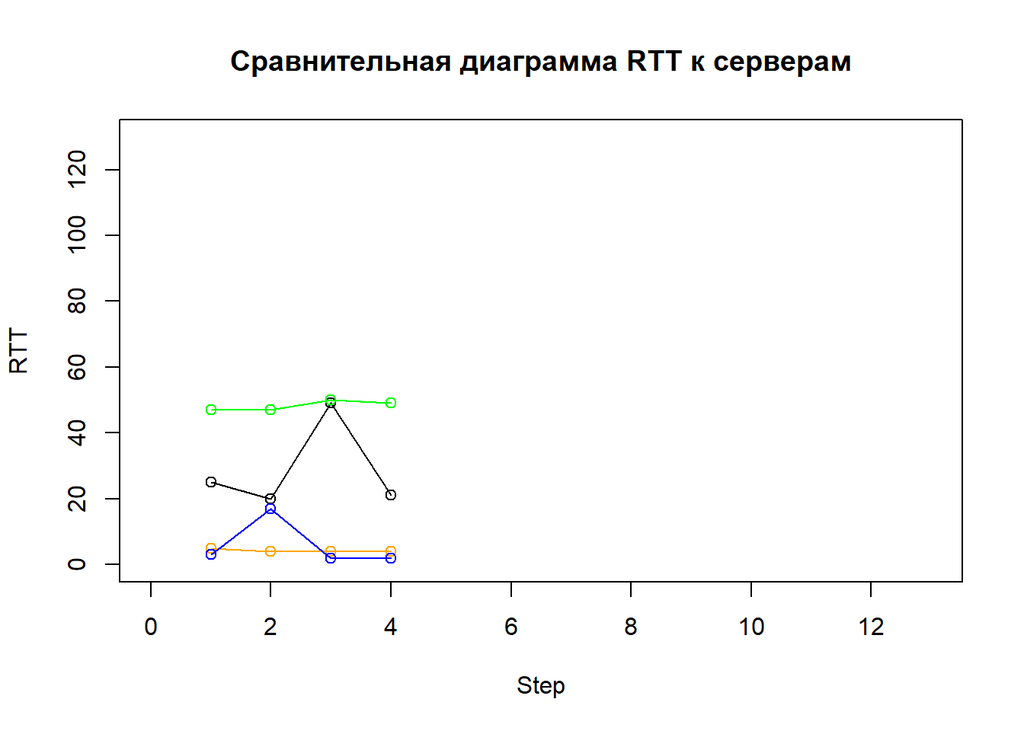